# Web Analytics

# propensity score matching

```r
m_ps<-glm(test~age+friend_cnt+avg_friend_age+avg_friend_male+friend_country_cnt+songsListened+lovedTracks+posts+playlists+shouts+adopter+tenure+good_country,family =binomial,data=dt2)
summary(m_ps)
```

```
##
## Call:
## glm(formula = test ~ age + friend_cnt + avg_friend_age + avg_friend_male +
##     friend_country_cnt + songsListened + lovedTracks + posts +
##     playlists + shouts + adopter + tenure + good_country, family = binomial,
##     data = dt2)
##
## Deviance Residuals:
##     Min       1Q   Median       3Q      Max
## -4.3520  -0.5621  -0.4143  -0.2960   2.5603
##
## Coefficients:
##                      Estimate Std. Error z value Pr(>|z|)
## (Intercept)        -5.111e+00  7.619e-02 -67.086  < 2e-16 ***
## age                 1.838e-02  2.786e-03   6.596 4.23e-11 ***
## friend_cnt          3.084e-02  1.038e-03  29.713  < 2e-16 ***
## avg_friend_age      7.785e-02  3.479e-03  22.376  < 2e-16 ***
## avg_friend_male     2.484e-01  5.058e-02   4.910 9.09e-07 ***
## friend_country_cnt  1.104e-01  4.767e-03  23.154  < 2e-16 ***
## songsListened       6.417e-06  5.136e-07  12.494  < 2e-16 ***
## lovedTracks         5.557e-04  5.612e-05   9.901  < 2e-16 ***
## posts               5.248e-04  2.613e-04   2.008  0.04465 *
## playlists          -5.993e-03  1.271e-02  -0.472  0.63717
## shouts             -5.729e-05  3.790e-05  -1.512  0.13058
## adopter             8.039e-01  4.423e-02  18.176  < 2e-16 ***
## tenure             -2.094e-03  7.799e-04  -2.684  0.00727 **
## good_country        5.934e-02  2.939e-02   2.019  0.04351 *
## ---
## Signif. codes:  0 '***' 0.001 '**' 0.01 '*' 0.05 '.' 0.1 ' ' 1
##
## (Dispersion parameter for binomial family taken to be 1)
##
##     Null deviance: 46640  on 43826  degrees of freedom
## Residual deviance: 33856  on 43813  degrees of freedom
## AIC: 33884
##
## Number of Fisher Scoring iterations: 6
```

# calculate the propensity score

```r
prs_df<-data.frame(pr_score=predict(m_ps,type="response"),treatment=m_ps$model$test)
head(prs_df)
```

```
##     pr_score treatment
## 1 0.08417235         0
## 2 0.13814668         0
## 3 0.07621456         0
## 4 0.23069166         1
## 5 0.67574975         0
## 6 0.20448624         0
```

# examing the region of common support

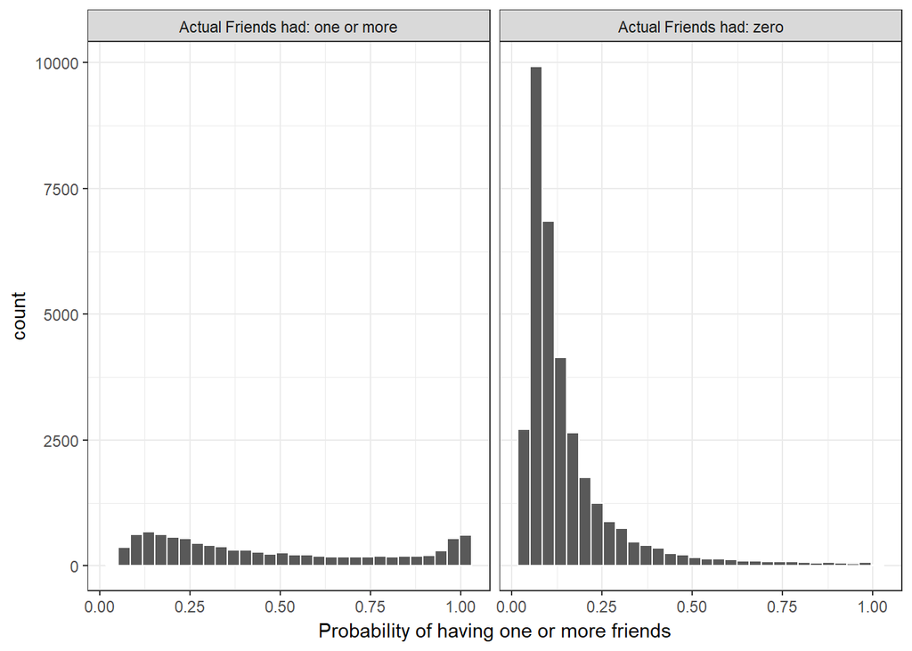

```r
labs <- paste("Actual Friends had:", c("one or more", "zero"))
prs_df %>%
  mutate(test = ifelse(treatment== 1, labs[1], labs[2])) %>%
  ggplot(aes(x = pr_score)) +
  geom_histogram(color = "white") +
  facet_wrap(~test) +
  xlab("Probability of having one or more friends") +
  theme_bw()
```

# therefore, from the graph, we can see that for treatment group, there are many samples who should have more friends had zero friend; while there are many samples who should have zero friends had many friends, making our matching feasible.

# Executing a matching alogorithm

```r
mod_match<-matchit(test~age+friend_cnt+avg_friend_age+avg_friend_male+friend_country_cnt+songsListened+lovedTracks+posts+playlists+shouts+adopter+tenure+good_country,method="nearest",data=dt2)
```

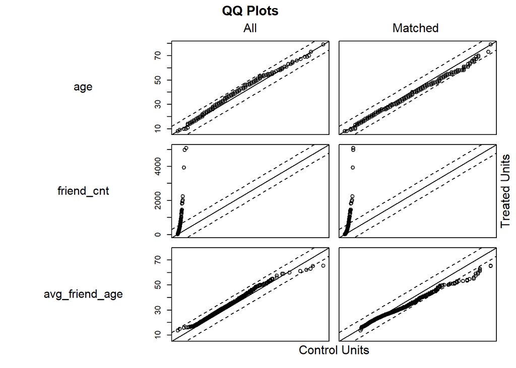

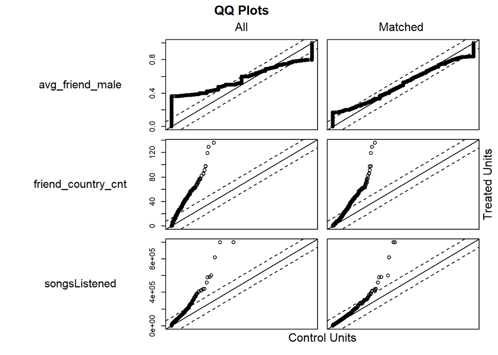

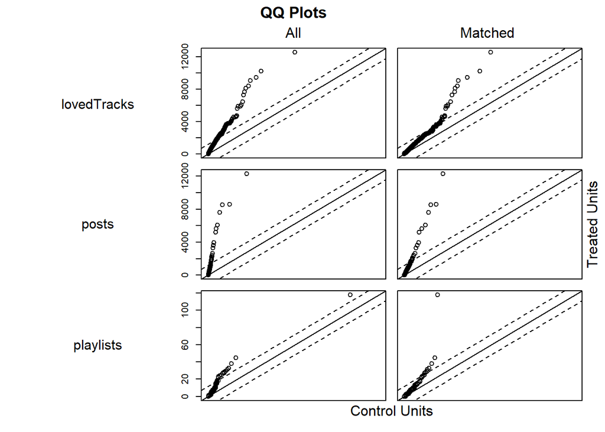

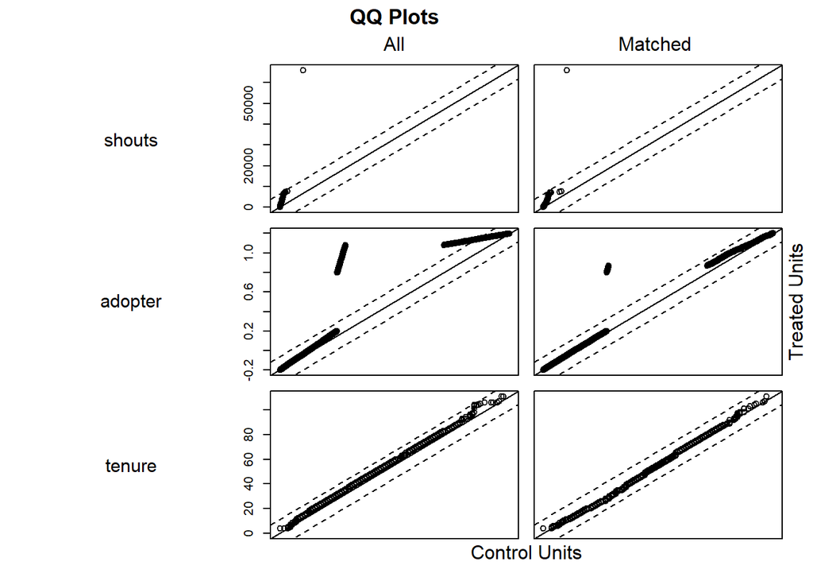

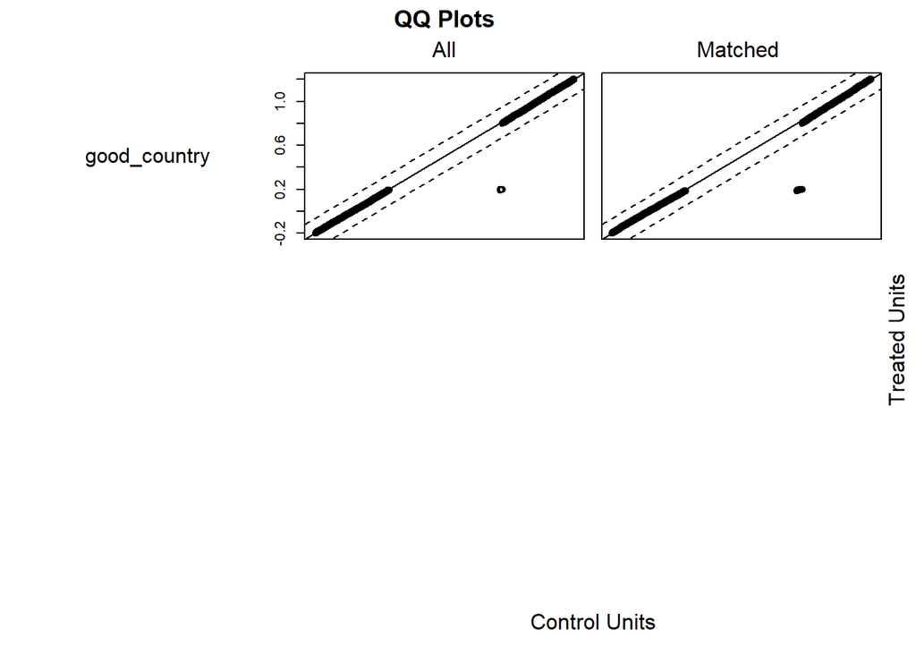

```r
plot(mod_match)
```

#creat a dataframe containing only the matched observations

```r
dta_m<-match.data(mod_match)
dim(dta_m)
```

```
## [1] 19646    18
```

# Inspection: difference-in-means

```r
HN_cov<-c("age","friend_cnt","avg_friend_age","avg_friend_male","friend_country_cnt","songsListened","lovedTracks","posts","playlists","shouts","adopter","tenure","good_country")
dta_m %>%
  group_by(test) %>%
  select(one_of(HN_cov)) %>%
  summarise_all(funs(mean))
```

```
## # A tibble: 2 x 14
##    test      age friend_cnt avg_friend_age avg_friend_male
##   <dbl>    <dbl>      <dbl>          <dbl>           <dbl>
## 1     0 26.28016   21.21358       26.49360       0.6532951
## 2     1 25.37321   54.02097       25.39043       0.6358077
## # ... with 9 more variables: friend_country_cnt <dbl>,
## #   songsListened <dbl>, lovedTracks <dbl>, posts <dbl>, playlists <dbl>,
## #   shouts <dbl>, adopter <dbl>, tenure <dbl>, good_country <dbl>
```

```r
lapply(HN_cov, function(v) {
    t.test(dta_m[, v] ~ dta_m$test)
})
```

```
## [[1]]
##
##  Welch Two Sample t-test
##
## data:  dta_m[, v] by dta_m$test
## t = 8.5675, df = 19377, p-value < 2.2e-16
## alternative hypothesis: true difference in means is not equal to 0
## 95 percent confidence interval:
##  0.6994598 1.1144463
## sample estimates:
## mean in group 0 mean in group 1
##        26.28016        25.37321
##
##
## [[2]]
##
##  Welch Two Sample t-test
##
## data:  dta_m[, v] by dta_m$test
## t = -24.999, df = 10490, p-value < 2.2e-16
## alternative hypothesis: true difference in means is not equal to 0
## 95 percent confidence interval:
##  -35.37980 -30.23498
## sample estimates:
## mean in group 0 mean in group 1
##        21.21358        54.02097
##
##
## [[3]]
##
##  Welch Two Sample t-test
##
## data:  dta_m[, v] by dta_m$test
## t = 12.944, df = 18472, p-value < 2.2e-16
## alternative hypothesis: true difference in means is not equal to 0
## 95 percent confidence interval:
##  0.9361252 1.2702272
## sample estimates:
## mean in group 0 mean in group 1
##        26.49360        25.39043
```

[output cut: 125 more lines]

```
##        47.58984        46.54871
##
##
## [[13]]
##
##  Welch Two Sample t-test
##
## data:  dta_m[, v] by dta_m$test
## t = 3.519, df = 19639, p-value = 0.0004342
## alternative hypothesis: true difference in means is not equal to 0
## 95 percent confidence interval:
##  0.01064308 0.03740741
## sample estimates:
## mean in group 0 mean in group 1
##       0.3673012       0.3432760
```

# Estimating treatment effect

```r
with(dta_m,t.test(adopter~test))
```

```
##
##  Welch Two Sample t-test
##
## data:  adopter by test
## t = -5.8501, df = 19529, p-value = 4.992e-09
## alternative hypothesis: true difference in means is not equal to 0
## 95 percent confidence interval:
##  -0.04104508 -0.02044326
## sample estimates:
## mean in group 0 mean in group 1
##       0.1467983       0.1775425
```

```r
glm_treat2 <- glm(adopter ~ test+age+friend_cnt+avg_friend_age+avg_friend_male+friend_country_cnt+songsListened+lovedTracks+posts+playlists+shouts+adopter+tenure+good_country, family=binomial, data = dta_m)
summary(glm_treat2)
```

```
##
## Call:
## glm(formula = adopter ~ test + age + friend_cnt + avg_friend_age +
##     avg_friend_male + friend_country_cnt + songsListened + lovedTracks +
##     posts + playlists + shouts + adopter + tenure + good_country,
##     family = binomial, data = dta_m)
##
## Deviance Residuals:
##     Min       1Q   Median       3Q      Max
## -3.0899  -0.6091  -0.5569  -0.4832   2.2109
##
## Coefficients:
##                      Estimate Std. Error z value Pr(>|z|)
## (Intercept)        -1.884e+00  1.093e-01 -17.235  < 2e-16 ***
## test                1.626e-01  4.090e-02   3.976 7.00e-05 ***
## age                 2.151e-02  3.614e-03   5.951 2.67e-09 ***
## friend_cnt          4.245e-04  2.547e-04   1.666  0.09566 .
## avg_friend_age     -1.305e-02  4.961e-03  -2.630  0.00853 **
## avg_friend_male     1.580e-02  8.216e-02   0.192  0.84746
## friend_country_cnt -1.103e-02  3.563e-03  -3.095  0.00197 **
## songsListened       3.370e-06  4.944e-07   6.817 9.31e-12 ***
## lovedTracks         4.918e-04  4.490e-05  10.953  < 2e-16 ***
## posts               1.510e-04  8.829e-05   1.710  0.08731 .
## playlists           7.433e-02  1.338e-02   5.557 2.75e-08 ***
## shouts              1.089e-04  7.159e-05   1.521  0.12816
## tenure             -3.526e-03  1.105e-03  -3.191  0.00142 **
## good_country       -3.638e-01  4.330e-02  -8.402  < 2e-16 ***
## ---
## Signif. codes:  0 '***' 0.001 '**' 0.01 '*' 0.05 '.' 0.1 ' ' 1
##
## (Dispersion parameter for binomial family taken to be 1)
##
##     Null deviance: 17416  on 19645  degrees of freedom
## Residual deviance: 16996  on 19632  degrees of freedom
## AIC: 17024
##
## Number of Fisher Scoring iterations: 4
```

```r
print(exp(glm_treat2$coefficients[1:14]))
```

```
##        (Intercept)               test                age
##          0.1520344          1.1766083          1.0217399
##         friend_cnt     avg_friend_age    avg_friend_male
##          1.0004246          0.9870352          1.0159300
## friend_country_cnt      songsListened        lovedTracks
##          0.9890336          1.0000034          1.0004919
##              posts          playlists             shouts
##          1.0001510          1.0771601          1.0001089
##             tenure       good_country
##          0.9964807          0.6950245
```

# aftering doing propensity score matching, as the result shows,keeping other covariates constant, compared with users who have zero subscriber friend, users have one or more subsriber friends have 17% higher chance to be an adopter.

# Regression for the model

```r
#based on the visualization in part 2, variables to be included in the model could be:
reg_val<-c( "male","subscriber_friend_cnt","good_country","friend_cnt","avg_friend_age","friend_country_cnt","songsListened","lovedTracks","posts","playlists","shouts","adopter")

fit.glm <- glm(adopter ~ male+good_country+subscriber_friend_cnt+friend_cnt+avg_friend_age+friend_country_cnt+songsListened+lovedTracks+posts+playlists+shouts,family = binomial,data = dt2)

summary(fit.glm)
```

```
##
## Call:
## glm(formula = adopter ~ male + good_country + subscriber_friend_cnt +
##     friend_cnt + avg_friend_age + friend_country_cnt + songsListened +
##     lovedTracks + posts + playlists + shouts, family = binomial,
##     data = dt2)
##
## Deviance Residuals:
##     Min       1Q   Median       3Q      Max
## -5.4957  -0.4126  -0.3509  -0.2932   2.7104
##
## Coefficients:
##                         Estimate Std. Error z value Pr(>|z|)
## (Intercept)           -4.158e+00  9.014e-02 -46.133  < 2e-16 ***
## male                   4.448e-01  4.102e-02  10.843  < 2e-16 ***
## good_country          -4.142e-01  4.054e-02 -10.217  < 2e-16 ***
## subscriber_friend_cnt  9.725e-02  1.077e-02   9.031  < 2e-16 ***
## friend_cnt            -4.515e-03  5.000e-04  -9.029  < 2e-16 ***
## avg_friend_age         4.273e-02  3.253e-03  13.134  < 2e-16 ***
## friend_country_cnt     4.401e-02  3.658e-03  12.032  < 2e-16 ***
## songsListened          7.016e-06  4.914e-07  14.278  < 2e-16 ***
## lovedTracks            7.075e-04  4.932e-05  14.344  < 2e-16 ***
## posts                  7.162e-05  9.507e-05   0.753    0.451
## playlists              6.223e-02  1.349e-02   4.613 3.96e-06 ***
## shouts                 9.798e-05  8.227e-05   1.191    0.234
## ---
## Signif. codes:  0 '***' 0.001 '**' 0.01 '*' 0.05 '.' 0.1 ' ' 1
##
## (Dispersion parameter for binomial family taken to be 1)
##
##     Null deviance: 24537  on 43826  degrees of freedom
## Residual deviance: 22659  on 43815  degrees of freedom
## AIC: 22683
##
## Number of Fisher Scoring iterations: 5
```

# odds ratio

```r
print(exp(fit.glm$coefficients[1:12]))
```

```
##           (Intercept)                  male          good_country
##            0.01563431            1.56015560            0.66084227
## subscriber_friend_cnt            friend_cnt        avg_friend_age
##            1.10214027            0.99549538            1.04365596
##    friend_country_cnt         songsListened           lovedTracks
##            1.04499132            1.00000702            1.00070773
##                 posts             playlists                shouts
##            1.00007162            1.06420469            1.00009799
```